# Generate PUMA to Place Crosswalk File

Author

JP Walsh

Published

May 28, 2026

*Program for the creation of the PUMA to place crosswalk for UMF predictors*

## Executive Summary

This document generates PUMA-to-Place crosswalk files for the UMF mobility metrics project. **NEW**: This version includes 2000 PUMA boundaries to support historical analysis back to the 2000 Census period.

**Three crosswalk periods:** - **2000 PUMA → 2014 Place** (for 2000-2011 ACS data) - **2012 PUMA → 2014 Place** (for 2012-2021 ACS data) - **2020 PUMA → 2020 Place** (for 2022+ ACS data)

This enables consistent geographic analysis across 25+ years of Census data.

Program: Initially written by Tina Chelidze and updated by JP Walsh 2022-2023.

Primary data derived from the University of Missouri’s [geographic correspondence engine](https://mcdc.missouri.edu/applications/geocorr.html).

Based on processes developed by Paul Johnson and Kevin Werner in SAS.

- Housekeeping
- Read data
- Clean crosswalks
- Create quality variable
- Write files

## Housekeeping

Read in packages for use.

```r
library(tidyverse)
library(Hmisc)
library(reactable)

options(scipen = 999)

cw_files <- c("puma_place_2020", "puma_place_2010", "puma_place_2k")
```

## Read data

Read the PUMA to Place crosswalks from the raw data file in the geographic-crosswalks folder. The project is currently using three crosswalk files that are utilized based on the year of the Census data. For 2022 ACS and onward we use a crosswalk going from 2020 PUMA to 2020 Place. For pre-2022 ACS data, we use a crosswalk from 2012 PUMA to 2014 Place for 2012 to 2021 ACS and we use a crosswalk from 2K PUMA to 2014 Place for pre-2012 ACS.

## Data Sources Detail

The GeoCorr website allows for a variety of selections in creating your crosswalk file. The selections used to create the files read here are detailed below:

### GeoCorr Configuration Parameters

| Parameter | 2000 PUMAs | 2012 PUMAs | 2020 PUMAs |
| --- | --- | --- | --- |
| Source Geography | 2000 PUMA | 2012 PUMA | 2020 PUMA |
| Target Geography | 2014 Place | 2014 Place | 2020 Place |
| Weight Variable | 2010 Census Pop | 2010 Census Pop | 2020 Census Pop |
| Coverage | All US States | All US States | All US States |

**Rationale**: Using 2010 population weights for both 2000 and 2012 PUMAs ensures consistency for pre-2020 Census period analysis.

[Geocorr2018](https://mcdc.missouri.edu/applications/geocorr2018.html) *States:* All *Source geography:* 2012 PUMA & 2K PUMA *Target geography:* 2014 Place (City, Town, Village, CDP, etc.) *Weighting variable:* Population (2010 census) *Output Options:* Format CSV & Generate second allocation factor

[Geocorr2022](https://mcdc.missouri.edu/applications/geocorr2022.html) *States:* All *Source geography:* 2020 PUMA *Target geography:* 2020 Place (City, Town, Village, CDP, etc.) *Weighting variable:* Population (2020 census) *Output Options:* Format CSV & Generate second allocation factor

Read in the crosswalk files from the raw folder inside the geographic-crosswalk data folder.

```r
puma_place_2020 <- read_csv(here::here("geographic-crosswalks", "data", "raw", "geocorr2022_puma_place_2020.csv"))
puma_place_2010 <- read_csv(here::here("geographic-crosswalks", "data", "raw", "geocorr2018_puma_place_2010.csv")) %>%
  rename(place = placefp14)
puma_place_2k <- read_csv(here::here("geographic-crosswalks", "data", "raw", "geocorr2018_puma_place_2k.csv"))%>%
  rename(place = placefp14)
```

Check that all states are present in the raw data and count the number of unique places in each state.

```r
check_unique_place <- function(df_name) {
  df <- get(df_name)
  df %>%
    select(state, place) %>%
    unique() %>%
    mutate(cw_period = df_name)
}

# Validation function
validate_crosswalk <- function(df, period_name) {
  cat("Validation for", period_name, "period:\n")
  cat("- Rows:", nrow(df), "\n")
  cat("- Unique PUMAs:", n_distinct(df$puma), "\n")
  cat("- Unique Places:", n_distinct(paste(df$statefip, df$place)), "\n")
  cat("- Missing afact values:", sum(is.na(df$afact)), "\n")
  cat("- Zero afact values:", sum(df$afact == 0, na.rm = TRUE), "\n\n")
}

coverage_summary <- map_dfr(cw_files, check_unique_place) %>%
  group_by(state, cw_period) %>%
  summarise(unique_places = n(), .groups = "drop") %>%
  pivot_wider(names_from = "cw_period", values_from = unique_places) %>%
  select(state, puma_place_2k, puma_place_2010, puma_place_2020)

coverage_summary %>% reactable()
```

| state | puma_place_2k | puma_place_2010 | puma_place_2020 |
| --- | --- | --- | --- |
| 01 | 581 | 581 | 594 |
| 02 | 353 | 353 | 351 |
| 04 | 452 | 452 | 466 |
| 05 | 541 | 541 | 627 |
| 06 | 1510 | 1510 | 1608 |
| 08 | 459 | 459 | 481 |
| 09 | 143 | 143 | 216 |
| 10 | 78 | 78 | 80 |
| 11 | 1 | 1 | 1 |
| 12 | 920 | 920 | 956 |

[output cut: 43 more lines]

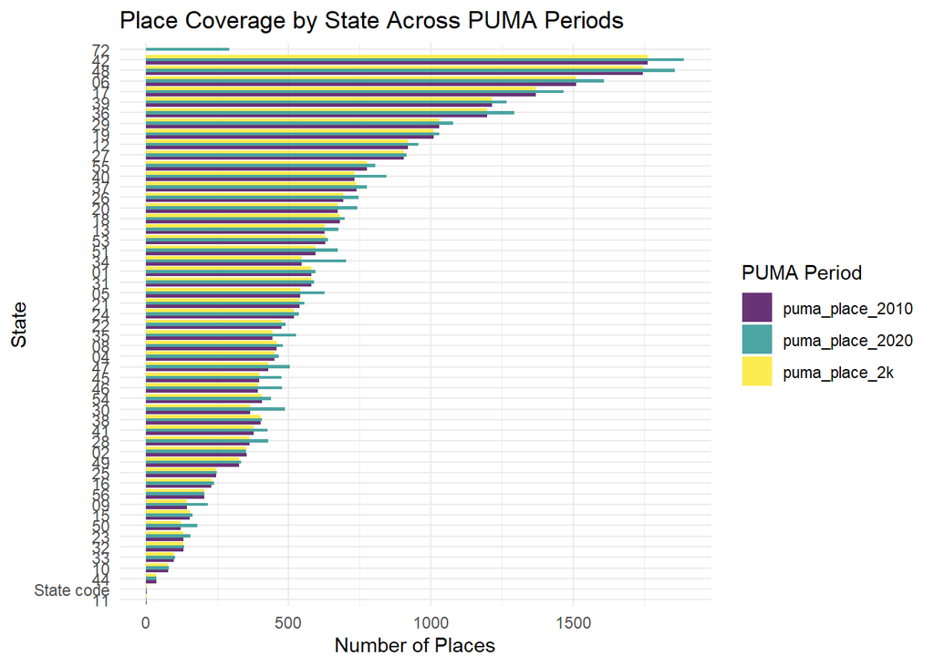

```r
# Coverage visualization
coverage_summary %>%
  pivot_longer(cols = -state, names_to = "cw_period", values_to = "unique_places") %>%
  ggplot(aes(x = reorder(state, unique_places), y = unique_places, fill = cw_period)) +
  geom_col(position = "dodge", alpha = 0.8) +
  coord_flip() +
  scale_fill_viridis_d(name = "PUMA Period") +
  labs(
    title = "Place Coverage by State Across PUMA Periods",
    x = "State",
    y = "Number of Places"
  ) +
  theme_minimal()
```

## Clean crosswalks

Filter out the row containing metadata and select only needed variables.

```r
# Consolidated processing functions
clean_cw <- function(.x,  .cw_period) {
  .x %>%
  rename_with(tolower) %>%
  filter(!str_detect(state, "State")) %>%
  select(state, starts_with("puma"), -ends_with("name"), place, starts_with("pop"), afact, afact2) %>%
  mutate(crosswalk_period = .cw_period)
}

create_geo_indicators <- function(.x) {
  .x %>%
    rename(
    puma = starts_with("puma"),
    statefip = state
    ) %>%
  mutate(
    statefip = sprintf("%0.2d", as.numeric(statefip)),
    puma = sprintf("%0.5d", as.numeric(puma)),
    place = sprintf("%0.5d", as.numeric(place)),
    across(contains("afact"), ~ as.double(.)),
    across(contains("pop"), ~ as.double(.))
  )
}

# Process datasets with consolidated functions
puma_place_2020 <- clean_cw(puma_place_2020, .cw_period = "2022")
puma_place_2010 <- clean_cw(puma_place_2010, .cw_period = "2012")
puma_place_2k <- clean_cw(puma_place_2k, .cw_period = "2k")

puma_place_2020 <- create_geo_indicators(puma_place_2020)
puma_place_2010 <- create_geo_indicators(puma_place_2010)
puma_place_2k <- create_geo_indicators(puma_place_2k)
```

We want to limit the crosswalk only to Places that will be used in the final mobility metric data - this will help limit the size of future data steps. Bring in the Places population file (place-populations.csv) to select only places included in the UMF data. Keep only one year of place information.

```r
places <- read_csv(here::here("geographic-crosswalks", "data", "place-populations.csv")) %>%
  filter(year == 2024) %>%
  select(-population, -year)
```

Rename the Place population variables to prep for merge.

```r
places <- places %>%
  rename(statefip = state)
```

# Left join to filter crosswalks to only relevant places

```r
puma_place_2020 <- left_join(places, puma_place_2020, by=c("statefip","place"))
puma_place_2010 <- left_join(places, puma_place_2010, by=c("statefip","place"))
puma_place_2k <- left_join(places, puma_place_2k, by=c("statefip","place"))
```

# Apply validation to each dataset

We can see that some of the rows in the Geocorr data have msising or zero afact values. We clean these in the next step.

```r
validate_crosswalk(puma_place_2020, "2022")
```

```
Validation for 2022 period:
- Rows: 1578
- Unique PUMAs: 878
- Unique Places: 486
- Missing afact values: 0
- Zero afact values: 28
```

```r
validate_crosswalk(puma_place_2010, "2012")
```

```
Validation for 2012 period:
- Rows: 1543
- Unique PUMAs: 806
- Unique Places: 486
- Missing afact values: 1
- Zero afact values: 32
```

```r
validate_crosswalk(puma_place_2k, "2k")
```

```
Validation for 2k period:
- Rows: 1347
- Unique PUMAs: 548
- Unique Places: 486
- Missing afact values: 1
- Zero afact values: 49
```

# Create quality varaible

Add the necessary components to the crosswalk for producing a data quality flag.

Create flags in the PUMA-place crosswalk for places where a high percentage of the data comes from outside of the Place. Per agreed upon guidance, 75% or more from the place is good, below 35% is bad, in between is marginal. This is calculated by taking the product of percentage of PUMA in place and percentage of place in PUMA for each place-PUMA pairing, and summing across the place.

```r
#Function for setting quality variables
geographic_allocation <- function(.x) {
  .x %>%
    mutate(
    geographic_allocation_quality =
      case_when(
        sum_products >= 0.75 ~ 1,
        sum_products >= 0.35 ~ 2,
        sum_products < 0.35 ~ 3
      )
    )
}

puma_place_2020 <- puma_place_2020 %>%
  filter(afact != 0.000) %>%
  mutate(products = afact * afact2) %>%
  group_by(statefip, place) %>%
  mutate(
    sum_products = sum(products),
    place_pop = sum(pop20)
  ) %>%
  ungroup() %>%
  geographic_allocation()

puma_place_2010 <- puma_place_2010 %>%
  filter(afact != 0.000) %>%
  mutate(products = afact * afact2) %>%
  group_by(statefip, place) %>%
  mutate(
    sum_products = sum(products),
    place_pop = sum(pop10)
  ) %>%
  ungroup() %>%
  geographic_allocation()

puma_place_2k <- puma_place_2k %>%
  filter(afact != 0.000) %>%
  mutate(products = afact * afact2) %>%
  group_by(statefip, place) %>%
  mutate(
    sum_products = sum(products),
    place_pop = sum(pop10)
  ) %>%
  ungroup() %>%
  geographic_allocation()
```

All afacts now have values.

```r
validate_crosswalk(puma_place_2020, "2022")
```

```
Validation for 2022 period:
- Rows: 1550
- Unique PUMAs: 872
- Unique Places: 486
- Missing afact values: 0
- Zero afact values: 0
```

```r
validate_crosswalk(puma_place_2010, "2012")
```

```
Validation for 2012 period:
- Rows: 1510
- Unique PUMAs: 798
- Unique Places: 485
- Missing afact values: 0
- Zero afact values: 0
```

```r
validate_crosswalk(puma_place_2k, "2k")
```

```
Validation for 2k period:
- Rows: 1297
- Unique PUMAs: 543
- Unique Places: 485
- Missing afact values: 0
- Zero afact values: 0
```

## Comparative Data Quality Analysis

Visualize key variables across all three crosswalk periods for comparison.

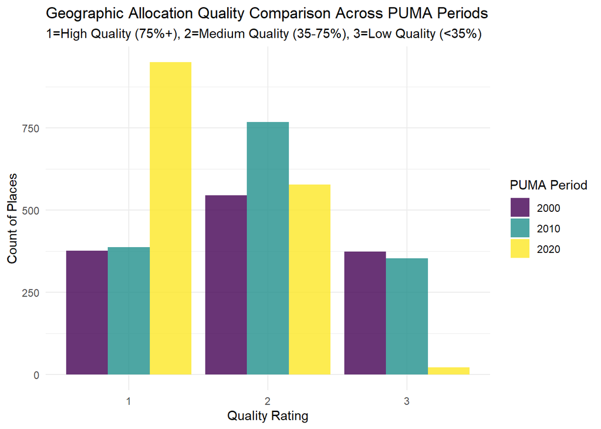

```r
# Create combined quality comparison
quality_comparison <- bind_rows(
  puma_place_2020 %>% select(crosswalk_period, geographic_allocation_quality) %>% mutate(type = "2020"),
  puma_place_2010 %>% select(crosswalk_period, geographic_allocation_quality) %>% mutate(type = "2010"),
  puma_place_2k %>% select(crosswalk_period, geographic_allocation_quality) %>% mutate(type = "2000")
)

quality_comparison %>%
  ggplot(aes(x = factor(geographic_allocation_quality), fill = type)) +
  geom_bar(position = "dodge", alpha = 0.8) +
  scale_fill_viridis_d(name = "PUMA Period") +
  labs(
    title = "Geographic Allocation Quality Comparison Across PUMA Periods",
    subtitle = "1=High Quality (75%+), 2=Medium Quality (35-75%), 3=Low Quality (<35%)",
    x = "Quality Rating",
    y = "Count of Places"
  ) +
  theme_minimal()
```

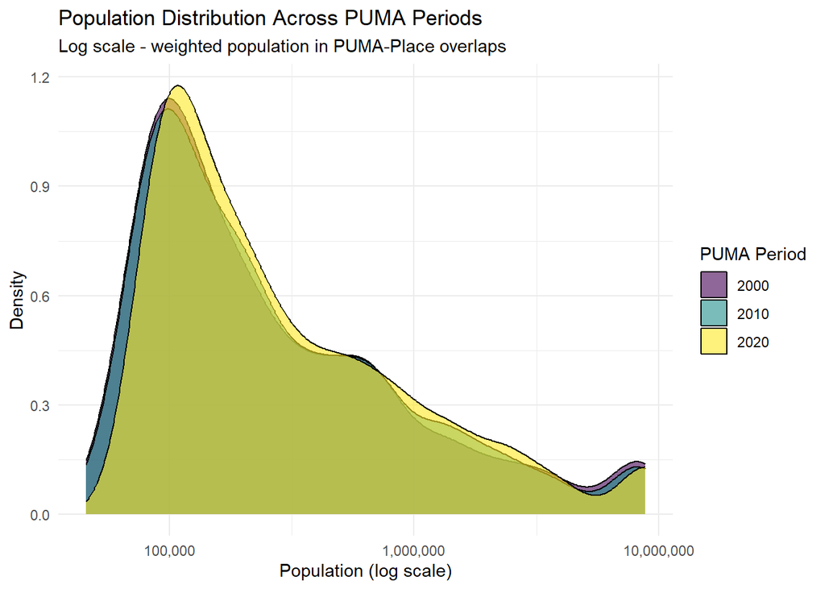

```r
# Combined population distribution
pop_combined <- bind_rows(
  puma_place_2020 %>% select(place_pop, crosswalk_period) %>% mutate(period = "2020"),
  puma_place_2010 %>% select(place_pop, crosswalk_period) %>% mutate(period = "2010"),
  puma_place_2k %>% select(place_pop, crosswalk_period) %>% mutate(period = "2000")
)

pop_combined %>%
  ggplot(aes(x = place_pop, fill = period)) +
  geom_density(alpha = 0.6) +
  scale_x_log10(labels = scales::comma_format()) +
  scale_fill_viridis_d(name = "PUMA Period") +
  labs(
    title = "Population Distribution Across PUMA Periods",
    subtitle = "Log scale - weighted population in PUMA-Place overlaps",
    x = "Population (log scale)",
    y = "Density"
  ) +
  theme_minimal()
```

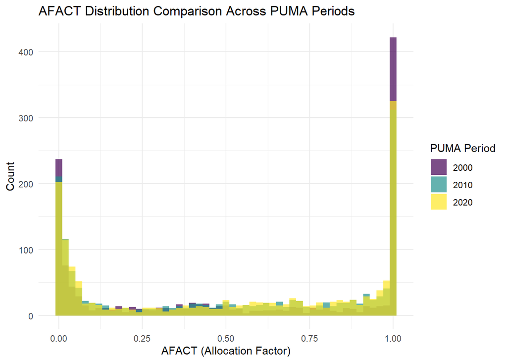

```r
# AFACT distribution comparison
afact_combined <- bind_rows(
  puma_place_2020 %>% select(afact, crosswalk_period) %>% mutate(period = "2020"),
  puma_place_2010 %>% select(afact, crosswalk_period) %>% mutate(period = "2010"),
  puma_place_2k %>% select(afact, crosswalk_period) %>% mutate(period = "2000")
)

afact_combined %>%
  ggplot(aes(x = afact, fill = period)) +
  geom_histogram(alpha = 0.7, position = "identity", binwidth = 0.02) +
  scale_fill_viridis_d(name = "PUMA Period") +
  labs(
    title = "AFACT Distribution Comparison Across PUMA Periods",
    x = "AFACT (Allocation Factor)",
    y = "Count"
  ) +
  theme_minimal()
```

The average sum of products in the 2020 crosswalk is 77% and 55% in the 2010 crosswalk (more PUMAs have good quality than less than good). It is expected that 2010 will have lower quality because the PUMA boundaries and place boundaries are removed by two years (2012 to 2014).

```r
puma_place_2k %>%
  select(sum_products) %>%
  summary()
```

```
  sum_products
 Min.   :0.02276
 1st Qu.:0.31359
 Median :0.52494
 Mean   :0.54834
 3rd Qu.:0.79755
 Max.   :1.00000
```

```r
puma_place_2010 %>%
  select(sum_products) %>%
  summary()
```

```
  sum_products
 Min.   :0.0193
 1st Qu.:0.3607
 Median :0.5421
 Mean   :0.5540
 3rd Qu.:0.7585
 Max.   :1.0000
```

```r
puma_place_2020 %>%
  select(sum_products) %>%
  summary()
```

```
  sum_products
 Min.   :0.2130
 1st Qu.:0.6828
 Median :0.7999
 Mean   :0.7736
 3rd Qu.:0.9265
 Max.   :1.0001
```

# Rename for consistency with county processing

```r
puma_place20 <- puma_place_2020 %>% rename(population = pop20)
puma_place10 <- puma_place_2010 %>% rename(population = pop10)
puma_place2k <- puma_place_2k %>% rename(population = pop10)
```

# Clean up intermediate objects for memory management

```r
rm(puma_place_2020, puma_place_2010, puma_place_2k)
```

# Combine all crosswalks with optimized memory usage

```r
puma_place <- puma_place20 %>%
  bind_rows(puma_place10, puma_place2k) %>%
  arrange(crosswalk_period, statefip, place) %>%
  select(crosswalk_period, statefip, place, puma, afact, afact2,
         population, products, sum_products, geographic_allocation_quality)
```

## Write files

Save as “puma_place” and year of population weight in the geographic-crosswalks data file.

```r
write_csv(puma_place, here::here("geographic-crosswalks", "data", "crosswalk_puma_to_place.csv"))
```